# La gobernanza oceánica integrada es necesaria en el Océano Atlántico Sudoccidental para fomentar las pesquerías, la conservación y la resiliencia al cambio climático

Juliano Palacios-Abrantes, Facundo Llompart, Luís Gustavo Cardoso, Omar Defeo, Ignacio Gianelli, Andrés J. Jaureguizar, Priscila F. M. Lopes, José Angel A. Perez, Natali I. P. Piccolo, Alberto R. Piola, Andrei Polejack, Luciana F. Prado, Martin Saraceno

Marzo, 2026

[figure not shown]

- **NOTA: esta es una traducción al español del artículo:** *Integrated ocean governance is needed in the Southwest Atlantic Ocean to foster fisheries, conservation and resilience to climate change*, escrito por Palacios-Abrantes J.y colaboradores y que se puede encontrar en la siguiente [liga](https://doi.org/10.1007/s44289-026-00134-4).
  - Traducido por Juliano Palacios. Revisión técnica de Omar Defeo, Andrés Jaureguizar y Facundo Llompart.
- **Forma de citar**: Palacios-Abrantes, J., Llompart, F., Cardoso, L. G., Defeo, O., Gianelli, I., Jaureguizar, A. J., Lopes, P. F. M., Perez, J. A. A., Piccolo, N. I. P., Piola, A. R., Polejack, A., Prado, L. F. and Saraceno, M., 2026. Integrated ocean governance is needed in the Southwest Atlantic Ocean to foster fisheries, conservation and resilience to climate change. Discover Oceans, 3 (1), 19.

Descargar Artículo en Español

# Resumen

El Océano Atlántico Sudoccidental (ASO) es una región de importancia mundial, donde diversas masas de agua convergen y se mezclan, regulando el clima terrestre a la vez que sostiene pesquerías muy productivas y una alta biodiversidad marina. La conectividad ecológica es evidente, con múltiples especies y ecosistemas compartidos a través de diversas jurisdicciones y fronteras internacionales. Sin embargo, a pesar de los esfuerzos históricos y de los llamados más recientes hacia una gestión regional, el ASO es una de las grandes regiones oceánicas que aún carece de un órgano dedicado a la gobernanza oceánica que gestione los recursos compartidos. Esta desconexión resulta particularmente alarmante frente al cambio climático, que está alterando la distribución y abundancia de los stocks pesqueros, desplazando la distribución de las especies hacia los polos e intensificando la incertidumbre en la gestión de los recursos marinos. Un marco regional colaborativo, fundamentado en una gestión basada en el ecosistema, es necesario para fomentar una gestión sostenible y reforzar la resiliencia ante los impactos del cambio climático. A medida que Brasil da a lugar a una serie de reuniones de las Naciones Unidas sobre temas ambientales, la región enfrenta un momento decisivo: o mantenerse reactiva ante las estructuras de gobernanza externas, o bien diseñar proactivamente marcos que reflejen las prioridades regionales, equilibren las preocupaciones de soberanía e integren mejor la evidencia científica en la toma de decisiones. Por ello, invitamos a tomadores de decisiones, gestores y científicos a aprovechar el impulso político en América Latina para avanzar hacia una gobernanza oceánica integrada y multiescala, al tiempo que se fortalece la diplomacia científica oceánica en el ASO. Este es un llamado a contribuir a navegar un futuro incierto abordando los desafíos compartidos y priorizando la sostenibilidad oceánica en el ASO.

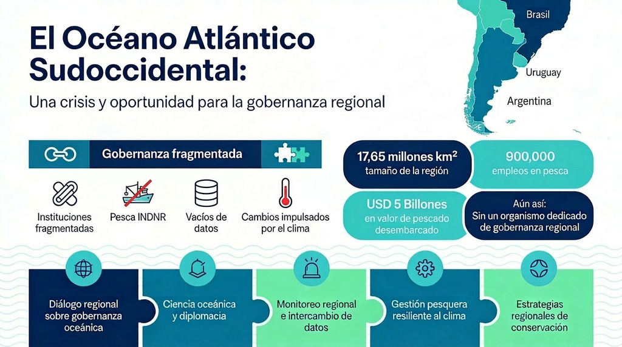

**Infográfico presentando um resumem de la investigacióm. Elaborado com ayuda de *Perpexity***

# El Océano Atlántico Sudoccidental: Una región de importancia ecológica y socioeconómica

Con una extensión de 17,65 millones de km² entre los 5°N y los 60°S, el ASO engloba diversas características oceánicas, biogeográficas y ecológicas que sustentan una biodiversidad excepcional y pesquerías de alto valor socioeconómico ([Fig. 1](https://link.springer.com/article/10.1007/s44289-026-00134-4/figures/1)). Distribuida dentro y más allá de las jurisdicciones nacionales, la región alberga puntos críticos de biodiversidad, corredores migratorios y hábitats críticos de desove, apareamiento, crianza y alimentación de múltiples especies importantes y vulnerables, incluyendo peces, tiburones, cefalópodos y mamíferos marinos como las ballenas jorobadas y australes, y orcas [1–3]. Estas características son el resultado de rasgos geomorfológicos, hidrográficos y biogeoquímicos que delimitan provincias biogeográficas y ecorregiones distintas, con altos niveles de endemismo y de cohesión ecológica [4,5].

*[Figura 1.](https://link.springer.com/article/10.1007/s44289-026-00134-4/figures/1) El Océano Atlántico Sudoccidental. La batimetría muestra las regiones someras en amarillo y las más profundas en morado. El cuadro negro representa el Área de Pesca Mayor 41 de la Organización de las Naciones Unidas para la Alimentación y la Agricultura. Las líneas blancas representan las Zonas Económicas Exclusivas de Brasil (continental), Uruguay y Argentina. Las líneas de contorno azules representan las distintas ecorregiones consideradas, mientras que las rojas representan eco-regiones fuera del ASO, según Spalding et al. 2007 [4]. Las líneas negras discontinuas representan las principales corrientes. NBC, Corriente del Norte de Brasil. SEC, Corriente Ecuatorial del Sur. BC, Corriente de Brasil. MC, Corriente de Malvinas. ACC, Corriente Circumpolar Antártica. SAC, Corriente de América del Sur. ZG, Giro de Zapiola.*

La importancia ecológica del ASO se extiende igualmente a las pesquerías ([Fig. 2](https://link.springer.com/article/10.1007/s44289-026-00134-4/figures/2)). Designado por la Organización de las Naciones Unidas para la Alimentación y la Agricultura (FAO) como Área de Pesca Mayor 41 ([Fig. 1](https://link.springer.com/article/10.1007/s44289-026-00134-4/figures/1)), el ASO cuenta con más de 32.000 embarcaciones artesanales e industriales, que emplean a 896.000 personas. En 2021, las capturas en estas pesquerías multiespecíficas se estimaron en 2 millones de toneladas, con un valor de 5 billones de dólares [6]. En el norte de Brasil (al norte de los 20°S), la plataforma continental sustenta pesquerías multiespecíficas de pequeña escala, aunque a menudo con una cobertura estadística limitada. Más al sur, las pesquerías industriales se han desarrollado a lo largo de las plataformas de Brasil, Uruguay y Argentina, dirigidas a stocks compartidos de alto valor comercial [7–9]. Además, en el ASO, la conectividad entre regiones es marcada. Por ejemplo, en invierno, los stocks de peces, camarones, langostinos y calamares se desplazan hacia el norte desde las plataformas patagónica septentrional y uruguaya hacia la plataforma sur de Brasil, donde representan un componente sustancial de la industria pesquera en esta productiva e importante región económica del país [10,11]. Esta conectividad resulta en un elevado número de stocks compartidos (transfronterizos y transzonales, Cuadro 1) en la composición de capturas de estos países ([Fig. 2b](https://link.springer.com/article/10.1007/s44289-026-00134-4/figures/2)) [12–14].

**Cuadro 1. Glosario de terminología incluida en el presente artículo.**

| **Término** | **Definición** |
| --- | --- |
| Circulación meridional de retorno del Atlántico (AMOC) | Sistema de corrientes oceánicas en el Océano Atlántico que transporta aguas superficiales cálidas y salinas hacia el norte y devuelve aguas más frías y profundas hacia el sur. Desempeña un papel críti… |
| Gestión basado en ecosistemas (GBE) | Gestión de recursos que considera la totalidad del sistema social-ecológico (es decir, incluidas las actividades humanas, los factores sociales y económicos) para mantener la integridad ecológica y el… |
| Escenario de altas emisiones de cambio climático (SSP5-8.5) | Escenario futuro de cambio climático más intenso que representa una alta forzante radiativa asociada al aumento de emisiones de gases de efecto invernadero, que conduce a un calentamiento global susta… |
| Pesca ilegal, no declarada y no reglamentada (INDNR) | Actividades pesqueras que violan las leyes nacionales, regionales o internacionales, o que se producen al margen de dichas leyes, socavando la sostenibilidad de los ecosistemas marinos. |
| Gobernanza oceánica | Marco colectivo de políticas, instituciones, procesos y prácticas a través de los cuales las sociedades gestionan el uso, la conservación y el desarrollo sostenible de los océanos y sus recursos. |
| Diplomacia científica oceánica | Término paragua para clasificar los fenómenos resultantes de las múltiples interacciones de la ciencia con las relaciones internacionales, incluyendo el asesoramiento científico en asuntos oceánicos, … |
| Organización Regional de Ordenación Pesquera (OROP) | Organismos internacionales en los cuales los países colaboran para gestionar y conservar los stocks pesqueros de valor que cruzan fronteras nacionales, como los stocks transfronterizos, solapantes y a… |
| Stocks transzonales altamente migratorios | Stocks de peces altamente migratorios que se distribuyen ampliamente entre aguas internacionales y Zonas Económicas Exclusivas (ZEE) no adyacentes. |
| Stocks transzonales | Stocks de peces que cruzan el límite entre la ZEE de uno o más países y alta mar. |
| Stocks transfronterizos | Stocks de peces que se distribuyen, en la totalidad o en parte de su ciclo de vida, en dos o más ZEE vecinas. |

La importancia ecológica y la rica productividad pesquera del ASO están sustentadas por condiciones oceanográficas únicas y complejas ([Fig. 1](https://link.springer.com/article/10.1007/s44289-026-00134-4/figures/1)). La región se caracteriza por una intensa mezcla entre aguas subtropicales y subantárticas influenciadas por corrientes de frontera occidental relativamente fuertes como la Corriente del Norte de Brasil (NBC), la Corriente de Brasil (BC) y la Corriente de Malvinas (MC) ([Fig. 1](https://link.springer.com/article/10.1007/s44289-026-00134-4/figures/1)) [15,16]. En combinación con zonas frontales, remolinos, surgencias y las descargas de las principales cuencas fluviales, estos procesos son responsables de de la elevada productividad de los ecosistemas [17–20]. La marcada variabilidad espacial y temporal de la región moldea la distribución y abundancia de las comunidades marinas, situando al ASO entre las regiones marinas más productivas del mundo [6,8,21,22].

*[Figura 2.](https://link.springer.com/article/10.1007/s44289-026-00134-4/figures/2) Riqueza de especies y capturas en el Océano Atlántico Sudoccidental. a) Riqueza de especies para todos los taxa (datos de AquaMaps/AquaX, www.aquamaps.org). Los polígonos en blanco y negro representan las áreas marinas protegidas de la región (datos del Centro Mundial de Monitoreo de la Conservación de las Naciones Unidas [23] y del Instituto Chico Mendes de Conservação da Biodiversidade [24]). b) Capturas en la ZEE de cada país procedentes de todos los stocks y de los stocks compartidos (datos de The Sea Around Us, www.searoundus.com según [25]).*

## Gobernanza oceánica en el OASO

Sin embargo, los esfuerzos integrados en materia de conservación y gobernanza pesquera siguen siendo limitados, como lo ilustra el Acuerdo sobre Medidas del Estado Rector del Puerto (AMERP). El AMERP es un acuerdo vinculante e instrumento clave del Código de Conducta para la Pesca Responsable. Exige a las partes que refuercen la supervisión de los buques pesqueros extranjeros para combatir la INDNR por parte de las flotas de pesca de aguas distantes. Su objetivo es reducir el incentivo de los buques que realizan pesca INDNR mediante la prohibición de desembarcar sus capturas en los puertos de las partes miembro del AMERP, al tiempo que se protegen los mercados nacionales e internacionales [28]. Sin embargo, en la actualidad, Uruguay es la única parte del ASO que ha ratificado el AMERP. El mejor ejemplo de cooperación trilateral fue quizás la Comisión Asesora Regional de Pesca para el Atlántico Sudoccidental (CARPAS), establecida por la FAO en 1962 [8]. CARPAS desempeñó un papel importante como Comisión Asesora Regional de Pesca para el Atlántico Sudoccidental, coordinando estadísticas pesqueras, promoviendo la investigación biológica y realizando evaluaciones de stocks. Sin embargo, CARPAS fue oficialmente abolida por la Resolución 13/97 de la Conferencia de la FAO en 1997, tras la creación de las ZEE y el establecimiento en 1976 de la Comisión Técnica Mixta del Frente Marítimo (CTMFM). La CTMFM evalúa el estado de los recursos pesqueros y propone medidas de gestión dentro de la Zona Común de Pesca Argentino-Uruguaya (ZCPAU). En la actualidad, la ZCPAU funciona como un área de soberanía compartida para los recursos pesqueros transfronterizos de Argentina y Uruguay. La CTMFM es reconocida por la FAO como el único organismo pesquero regional en el Atlántico Sudoccidental. Aunque existen sólidos arreglos bilaterales entre Argentina y Uruguay, la participación de Brasil ha permanecido comparativamente incipiente desde el fin de CARPAS, con la mayor parte de los esfuerzos impulsados por la cooperación científica clásica en una variedad de temas de investigación marina [2,7,8].

## Los desafíos abundan en el OASO

Las bien documentadas tensiones geopolíticas en el ASO continúan moldeando los enfoques regionales para la gobernanza oceánica y la gestión sostenible de los recursos marinos, con dinámicas que son agravadas de manera creciente por las presiones combinadas de la pesca INDNR y el cambio climático. Las iniciativas de conservación también siguen siendo limitadas, fragmentadas y frecuentemente desconectadas de la gestión pesquera, lo que socava la capacidad de salvaguardar los servicios ecosistémicos y de responder eficazmente a las presiones acumuladas, incluidas la sobrepesca, la degradación de hábitats y la variabilidad impulsada por el clima.

### Desafíos de gobernanza

Las pesquerías del ASO ilustran las tensiones entre gobernanza, competencia económica y sostenibilidad. La creciente presencia de flotas procedentes de Asia y Europa, con tecnologías de explotación de vanguardia, apuntan a recursos de alto valor como el calamar y el atún, y generan una competencia desigual con las flotas domésticas industriales y de pequeña escala [29,30]. Este desequilibrio se ve intensificado por los subsidios externos y el uso de banderas de conveniencia, que crean asimetrías de mercado y presiones sobre la seguridad alimentaria de las comunidades locales [31]. Paralelamente, estas dinámicas reflejan la expansión de las pesquerías no reglamentadas, como las del calamar, que explotan vacíos institucionales y reglamentarios en áreas de alta mar y en los márgenes de las jurisdicciones nacionales [32]. Este desafío se ve agravado por la ausencia de Brasil y Argentina en el AMERP. La proximidad geográfica entre Uruguay, Brasil y Argentina debilita la efectividad de este acuerdo, que se basa en parte en la dificultad de acceder a puertos fuera del marco del AMERP. Cuando los estados miembros del AMERP colindan con estados no miembros, los buques extranjeros pueden desviar su ruta hacia puertos no pertenecientes al AMERP o cambiar de bandera de manera oportuna para registros domésticos, práctica conocida como “domesticación de bandera” [31]. Entre 2016 y 2021, el número de visitas portuarias de buques que domesticaron la bandera en Brasil y Uruguay aumentó aproximadamente un 27% y un 57%, respectivamente [31]. Si bien la ratificación del AMERP representa un paso importante para combatir la pesca INDNR en la región, su efectividad depende en última instancia de la implementación, la coordinación y las medidas nacionales complementarias. En este contexto, el papel de Brasil como signatario (pero no como parte ratificante) y el estatus de Argentina como no signatario con controles portuarios existentes pone de relieve tanto las oportunidades como las limitaciones de depender del AMERP de forma aislada.

### Las brechas de datos limitan la conservación y la gestión pesquera efectivas

La conservación y gestión efectiva de las pesquerías en el OASO están limitadas por persistentes deficiencias de datos. Por ejemplo, las especies de preocupación para la conservación en la región, como los tiburones, cuentan con datos observacionales escasos [3]; la comprensión de la estructura de las comunidades de peces de arrecife se limita a subregiones específicas [37]; los ecosistemas de aguas profundas están prácticamente inexplorados visualmente [38]; y los datos pesqueros son frecuentemente incompletos [39]. Todas estas limitaciones tienen implicaciones para los esfuerzos regionales de proteger la biodiversidad marina y gestionar las pesquerías de forma sostenible.

Un obstáculo crítico para la gestión, incluida la gestión cooperativa, es la falta generalizada de datos fiables y consistentes sobre las pesquerías de la región, especialmente en el caso de las pesquerías de pequeña escala, las que crónicamente son subdeclaradas en toda América Latina y el Caribe [39]. Aunque no es exclusivo de esta zona, esta deficiencia de información puede ejemplificarse en el ASO con las pesquerías del norte de Brasil [40]. La recopilación sistemática de datos en Brasil ha sido inconsistente desde principios de la década de 2010, en gran medida debido a la inestabilidad institucional [40]. De 1990 a 2007, el Instituto Brasileño de Medio Ambiente (IBAMA) coordinó las estadísticas pesqueras nacionales con una amplia cobertura [41]. Sin embargo, las múltiples reformas institucionales posteriores desplazaron la responsabilidad hacia nuevos organismos, interrumpiendo la compilación de datos y resultando en una paralización casi total a nivel nacional [40]. Desde entonces, no se ha restablecido ningún programa nacional sostenido, y la información proviene principalmente de iniciativas estatales o académicas concentradas en el sur y sureste de Brasil, dejando en una situación de severa falta de monitoreo al norte y noreste, donde las pesquerías de pequeña escala superan las capturas industriales y sustentan la seguridad alimentaria local y los medios de vida [42–44]. En ausencia de un monitoreo sistemático, se desconoce el alcance de esta conectividad (y el estado de los stocks compartidos adicionales), lo que impide la gobernanza coordinada y la gestión adaptada al clima. Esta realidad tiene implicaciones adicionales para la gestión de los stocks transfronterizos en el norte/noreste de Brasil y la plataforma de las Guayanas, como es el caso del camarón tití (*Xiphopenaeus kroyeri*) y la corvina real (C*ynoscion acoupa*) [45,46].

### El cambio climático amplifica los desafíos existentes

El cambio climático ya está reconfigurado el ámbito oceanográfico y ecológico del ASO. La mayor parte de la región está experimentando un calentamiento superficial sustancial durante las últimas cuatro décadas [7,47] ([Fig. 3a](https://link.springer.com/article/10.1007/s44289-026-00134-4/figures/3)). Las olas de calor marino, acidez alta y bajo nivel de clorofila también han sido documentados recientemente en el Atlántico ecuatorial y sur [48]. Estos cambios ecológicos impulsados por el clima ya están induciendo profundas transformaciones económicas, sociales y ambientales en el ASO. Por ejemplo, la intensificación de la Corriente de Brasil [7,20] está alterando la distribución espacial de los ensambles de peces e invertebrados marinos a lo largo de las plataformas de Brasil y del norte argentino-uruguayo, aumentando la prevalencia de especies de aguas cálidas y reduciendo los componentes de aguas frías. Los registros de capturas y los datos observacionales revelan una tropicalización de las pesquerías, con especies de aguas cálidas cada vez más prevalentes mientras las de aguas frías declinan, reflejando desplazamientos de distribución hacia los polos [49,50].

Las proyecciones futuras del clima en la región señalan cambios continuos, aunque con un alto nivel de incertidumbre. Por ejemplo, dichas proyecciones muestran un debilitamiento de la Circulación Meridional de Retorno del Atlántico (AMOC), que resultaría en un Atlántico Sur más cálido (en superficie y en profundidad), con un grado de incertidumbre medio [20,51]. Además, los cambios futuros en los patrones de viento superficial podrían alterar la mezcla entre las principales corrientes del ASO y los procesos de mezcla vertical, con impactos potenciales sobre los flujos de nutrientes hacia el océano superior, la conectividad biológica, la distribución de especies y las pesquerías. En efecto, los modelos ecosistémicos proyectan que, en el transcurso del siglo XXI, las dinámicas ambientales reconfigurarán los patrones de riqueza de especies, lo que requerirá priorizar esfuerzos para salvaguardar la biodiversidad ante un clima cambiante ([Fig. 3b](https://link.springer.com/article/10.1007/s44289-026-00134-4/figures/3)). Como consecuencia, la gestión pesquera se verá desafiada por los desplazamientos en la distribución de las especies transfronterizas de importancia comercial hacia el sur ([Fig. 3c](https://link.springer.com/article/10.1007/s44289-026-00134-4/figures/3)), incluida la aparición de nuevos stocks compartidos ([Fig. 3d](https://link.springer.com/article/10.1007/s44289-026-00134-4/figures/3)), así como el desplazamiento en mayor grado de especies transzonales hacia alta mar (Fig. 3e) [52–54]. Por ejemplo, la Fig. 3e ilustra cómo el cambio climático podría modificar la proporción de la distribución de los stocks transzonales entre alta mar y las ZEE. Estos posibles cambios (p. ej., un stock que se desplaza fuera de la ZEE al aumentar su proporción en la alta mar) reducen la efectividad de las medidas de gestión unilaterales, incrementan la exposición a la pesca INDNR (p. ej., por parte de flotas de aguas distantes) y aumentan el riesgo de conflictos de gobernanza, a medida que los stocks se desplazan progresivamente fuera de las jurisdicciones nacionales. Abordar estos desafíos requerirá estrategias de gestión adaptativas y colaborativas capaces de responder a las dinámicas cambiantes de los stocks transzonales a través de las fronteras políticas.

*[Figura 3.](https://link.springer.com/article/10.1007/s44289-026-00134-4/figures/3) Impactos proyectados del cambio climático en la biodiversidad y los stocks compartidos del Océano Atlántico Sudoccidental. a) Tendencia lineal de la temperatura superficial del mar (TSM) para el período 1982-2020 (datos de la Administración Nacional Oceánica y Atmosférica - Centro Nacional de Datos Climáticos, Interpolación Óptima SST versión 2, Radiómetro Avanzado de Muy Alta Resolución). b) Cambios en la riqueza de especies proyectados para 2050 (datos de AquaMaps/AquaX). c) Cambios en la proporción compartida de stocks transfronterizos entre ZEE para 2050 (adaptado de [54]). d) Nuevos stocks que llegan para 2100 (adaptado de [52]). e) Cambios en la proporción de stocks solapantes entre ZEE y la alta mar para 2050 (adaptado de [53]). Todas las proyecciones representan un escenario de alto nivel de emisiones de cambio climático.*

## Mirando hacia el futuro

En un momento en que los océanos enfrentan desafíos sin precedentes derivados de las actividades antropogénicas, el multilateralismo está siendo erosionado por tensiones geopolíticas y las sociedades de todo el mundo experimentan una creciente polarización, el océano sigue siendo un conector y un interés compartido para la humanidad [55]. La gobernanza oceánica integrada y colaborativa ya no es una opción, sino una necesidad urgente para detener la degradación de los ecosistemas y fomentar su sostenibilidad a largo plazo [36]. Aunque los esfuerzos en materia de gobernanza, conservación y recopilación de datos en el ASO siguen siendo limitados, restricciones similares se observan incluso en regiones comparativamente más ricas en datos y con mayor desarrollo institucional. La limitante clave en el ASO no es, por tanto, la ausencia de capacidad en sí misma, sino la falta de mecanismos coordinados a escala regional que alineen el conocimiento científico existente, los esfuerzos de monitoreo y los instrumentos de gobernanza entre jurisdicciones. Así, el impulso político en América Latina puede beneficiar a la gobernanza oceánica al trascender las fronteras geopolíticas y las divisiones sectoriales, reconociendo al mismo tiempo que los procesos ecológicos y climáticos operan a escalas muy superiores a las jurisdicciones nacionales.

### Aprovechar el impulso político latinoamericano

El momento para iniciar diálogos regionales sobre el establecimiento de marcos cooperativos y el reposicionamiento de la región del ASO en el panorama global de gobernanza oceánica no podría ser más crítico. Mientras las tensiones geopolíticas erosionan aspectos del multilateralismo global, esta tendencia puede también crear espacios para el fortalecimiento de iniciativas de gobernanza regional, como lo ejemplifica el reciente acuerdo entre el bloque comercial sudamericano (MERCOSUR) y la Unión Europea sobre agricultura, un acuerdo cuyas negociaciones comenzaron hace más de 20 años [56]. En el ASO, los discursos emergentes enmarcan cada vez más la cooperación regional no solo como respuesta a las brechas de gobernanza global, sino también como una oportunidad para afirmar la autonomía estratégica y la gestión compartida de los recursos marinos [8]. Además, Brasil ocupa actualmente un papel central en la agenda ambiental global, siendo sede de una secuencia de reuniones internacionales, incluida la Conferencia de las Partes (COP) 30 de la Convención Marco de las Naciones Unidas sobre el Cambio Climático (UNFCCC, por sus siglas en inglés) en Belém en noviembre de 2025, así como el 3.er Simposio del Acuerdo BBNJ en marzo de 2026 y la Conferencia de la Década de los Océanos de la ONU en Río de Janeiro en 2027, entre otras. La COP30 en particular resaltó la urgencia de vincular clima y océano, reforzando la necesidad de estrategias de adaptación integradas para abordar el calentamiento de los mares, el desplazamiento de los stocks pesqueros, la acidificación y la pérdida de biodiversidad [57,58]. Brasil, durante la 3ª Conferencia de las Naciones Unidas sobre los Océanos (UNOC3, por sus siglas en inglés) en Niza, Francia (junio de 2025), integró una red de países que lanzaron el Desafío de las Contribuciones Determinadas a Nivel Nacional Azules (NDC Azules), un llamamiento global para que los países incluyan el océano en sus planes de acción nacionales y ambiciones climáticas. Una estrategia clave de las NDC Azules es fomentar pesquerías sostenibles y resistentes al clima, sustentadas en la gestión basada en ecosistemas y marcos de riesgo integrados. Paralelamente, con el Acuerdo BBNJ ratificado en enero de 2026 y Chile impulsando activamente la posibilidad de albergar su secretaría permanente, resulta estratégico y oportuno transformar las oportunidades diplomáticas en estrategias concretas sobre pesquerías, conservación y resiliencia climática que sirvan a los intereses regionales y globales. Finalmente, la Conferencia de la Década de los Océanos de la ONU subraya aún más el papel de la diplomacia científica oceánica como puente entre la producción de conocimiento y la acción política, alineándose con el llamamiento global a soluciones transformadoras impulsadas por la ciencia.

Estos eventos representan no solo hitos en la diplomacia ambiental global, sino también una rara confluencia de oportunidades para que la región consolide una estrategia coherente para el ASO. Los países pueden aprovechar estos eventos para articular prioridades compartidas, negociar marcos cooperativos y fortalecer los compromisos con una gestión basada en ecosistemas y resistente al clima. Los acuerdos internacionales, como el AMERP y el BBNJ ofrecen plataformas ya elaboradas que pueden adaptarse a las realidades regionales, proporcionando legitimidad y capacidad de aplicación. La urgencia reside no solo en responder a la aceleración del cambio ambiental, sino también en aprovechar este impulso diplomático actual para avanzar en una agenda sistemática, basada en la ciencia y fundamentada regionalmente para la gobernanza oceánica del ASO.

### Fortalecer la diplomacia científica oceánica

A pesar de los claros beneficios en términos de coordinación y sostenibilidad, la viabilidad de esta transformación sigue siendo contingente a la voluntad política, las sensibilidades de soberanía y la capacidad de conciliar distintas prioridades nacionales. Aprovechando el largo historial de cooperación científica de la región y el precedente establecido por mecanismos anteriores, el desarrollo de un marco institucional renovado podría servir como un primer paso pragmático y efectivo para fomentar una ciencia oceánica más integrada y cooperativa en el ASO. Al transitar desde esfuerzos de investigación aislados hacia una colaboración regional e institucional construida sobre una visión compartida, misión y agenda a largo plazo, los científicos podrían ayudar a trazar el camino hacia un ASO integrado. Es importante destacar que, como investigadores comprometidos, no es necesario esperar a que cambien los vientos cruzados del sistema político. Las iniciativas científicas colectivas pueden impulsar esta agenda a través de infraestructuras de datos compartidas, el desarrollo de expediciones de investigación conjuntas, la armonización de protocolos de monitoreo y la promoción de programas de intercambio de capacidades que conecten instituciones de toda la región. La revitalización e implementación de la ZOPACAS, por ejemplo, podría proporcionar una plataforma prometedora para fomentar la cooperación científica en asuntos oceánicos, incluida la investigación pesquera en el ASO [62]. Una colaboración similar basada en la ciencia tiene el potencial de fortalecer la gobernanza regional y promover la gestión compartida de los recursos marinos del ASO. Asimismo, en 2024, un grupo de científicos (incluyendo autores de este artículo) se reunió en el 20° Congreso Latinoamericano de Ciencias del Mar (COLACMAR), bajo los auspicios de la Asociación Latinoamericana de Ciencias del Mar (ALICMAR, https://www.alicmar.org/), en Brasil, para discutir precisamente los temas antes mencionados desde una perspectiva científica. Dada su larga trayectoria como organización científica regional, ALICMAR podría impulsar la gobernanza oceánica colaborativa en el ASO. La investigación en diplomacia científica oceánica muestra que la cooperación científica puede fortalecer la gobernanza regional al fomentar la confianza, promover el conocimiento compartido y desarrollar capacidades. Si bien no puede garantizarse que la integración científica repercuta en reformas de gobernanza, sí incentiva la coordinación entre jurisdicciones y destaca los beneficios mutuos de trabajar juntos hacia la sostenibilidad oceánica.

### Avanzar hacia una gobernanza y gestión oceánica integrada y multiescalar

La gobernanza oceánica en el ASO sigue fragmentada y en gran medida confinada a acuerdos bilaterales o mandatos sectoriales, los cuales no logran capturar la conectividad ecológica y la interdependencia socio-económica de la región. Dicha fragmentación contrasta con la existencia de marcos de integración regional más amplios como el MERCOSUR, que, a pesar de resultados mixtos, ha proporcionado espacios institucionales para la cooperación en algunos ámbitos de política no oceánica. A pesar de estos marcos, la brecha más urgente en la gobernanza oceánica del ASO reside en la ausencia de un marco cooperativo que integre de manera significativa a Brasil con los acuerdos bilaterales existentes entre Argentina y Uruguay. Esto sugiere que las limitaciones para la gobernanza oceánica regional van más allá de la ausencia de instituciones regionales per se. Las experiencias de otras regiones, como la Asociación de Naciones del Sudeste Asiático (ASEAN, por sus siglas en inglés) y la WCPFC, sugieren además que la cooperación incremental y de generación de confianza es posible incluso en contextos marítimos en disputa, ofreciendo lecciones potenciales para la gobernanza oceánica, aún más allá del sector pesquero. Dada la conectividad ecológica de los sistemas de plataforma y la naturaleza transfronteriza de varios stocks claves, un enfoque regional, pero flexible y policéntrico, representa una alternativa viable para enfrentar los desafíos que afronta la región. Dicho marco debería estar anclado en una gestión adaptativa y basada en la ciencia, un intercambio de datos fortalecido y la participación de las partes interesadas que incluya a las comunidades locales. Esta transformación no ocurrirá de la noche a la mañana; requiere tiempo para cultivar la capacidad y la solidez institucional necesarias, pero la persistencia a largo plazo en la cooperación regional puede arrojar resultados incluso en medio de circunstancias geopolíticas difíciles. También debe ser potenciada por una visión a largo plazo y en una agenda de investigación regional. Lejos de amenazar la soberanía, el establecimiento de una organización regional para la gobernanza cooperativa (p. ej., una OROP) podría fortalecerla al proporcionar a Argentina, Brasil y Uruguay un frente unido para defender sus recursos compartidos. Además, aunque la falta de una organización de cooperación regional mantiene la soberanía y autonomía de cada Estado, socava la resiliencia al cambio climático, las brechas de gobernanza y el avance de las flotas de aguas distantes [30]. Por tanto, la gobernanza efectiva en el ASO no puede limitarse únicamente a los Estados costeros. La creciente presencia de flotas pesqueras de aguas distantes, particularmente de China, España y Taiwán, que explotan stocks transzonales en áreas de alta mar adyacentes, requiere una participación negociada con actores extra-regionales a través de los instrumentos internacionales existentes [30].

La gestión oceánica en la región debería apuntar a medidas de gestión adaptativas y basadas en ecosistemas que aumenten la resiliencia de los ecosistemas y los stocks pesqueros ante el cambio climático [63]. El concepto de gestión resiliente al clima se fundamenta en la precaución, la eficiencia y la capacidad de respuesta política, y está diseñado para abordar las incertidumbres y las respuestas de los sistemas social-ecológicos marinos, considerando al mismo tiempo la integración de políticas, herramientas y medidas a diferentes escalas de espacio y el tiempo [64]. Por tanto, debe ser inclusiva de diversas partes interesadas, como la academia, los pescadores artesanales, la industria y las organizaciones no gubernamentales, a fin de establecer espacios formales para integrar sistemas de conocimiento plural y aspiraciones diversas. La bioregionalización de las áreas costeras y de plataforma [4] proporciona un marco macroescalar sólido para fortalecer el ajuste social-ecológico e institucional. La aplicación de este enfoque al ASO puede identificar hábitats sensibles y ecosistemas vulnerables, orientar medidas de gestión focalizadas y revelar impulsores ecológicos actualmente enmascarados por observaciones fragmentadas. Alinear las estructuras institucionales con estas dinámicas ambientales a gran escala fomentaría una gestión regional más efectiva, pesquerías resilientes y una mejor conservación de la biodiversidad. Por ejemplo, a medida que los países del ASO amplían sus áreas marinas protegidas (AMP) para alcanzar los objetivos 30x30 del CDB, la conservación regional puede fortalecerse mediante el establecimiento de una amplia red de AMP transfronterizas. Construyendo sobre las grandes AMP ya designadas en Argentina y Brasil, una red de conservación del ASO podría mejorar la protección de la biodiversidad, contribuir a la recuperación de los stocks sobreexplotados, mantener los servicios ecosistémicos, incrementar la conectividad ecológica y fomentar la resiliencia ante un clima cambiante [65]. Si bien estas grandes AMP representan logros de conservación significativos, también intersectan con dinámicas geopolíticas y de soberanía (p. ej., la disputa por las Islas Malvinas/Falkland). Por tanto, las iniciativas de conservación pueden avanzar en los objetivos de biodiversidad pero al mismo tiempo complicar la cooperación regional, subrayando la necesidad de estrategias de conservación que sean ecológicamente sólidas, políticamente conscientes e inclusivas a nivel regional. Además, dicha red debería articularse con alta mar a través del Acuerdo BBNJ, e integrar áreas ya designadas como Áreas de Importancia Ecológica o Biológica (AIEB) en el marco del CDB, como la Zona de Fractura Ecuatorial Atlántica (https://livinghighseas.org) o el Agujero Azul, una zona de alta productividad justo fuera de la ZEE de Argentina bajo intensa actividad pesquera por parte de flotas de aguas distantes [66,67].